## What’s going on with this data?

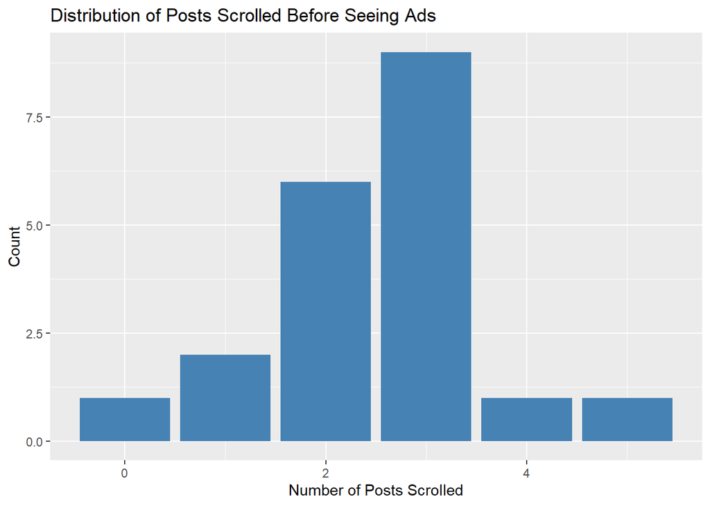

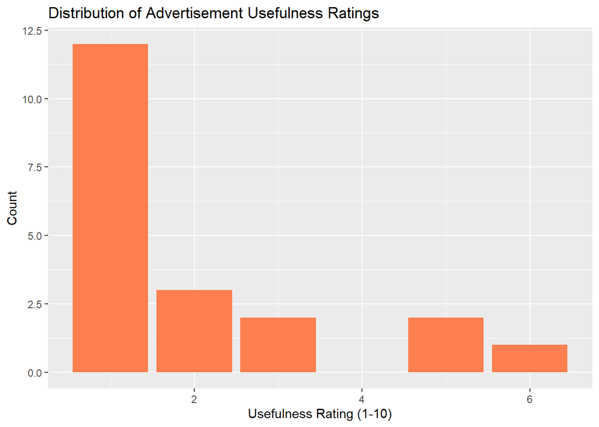

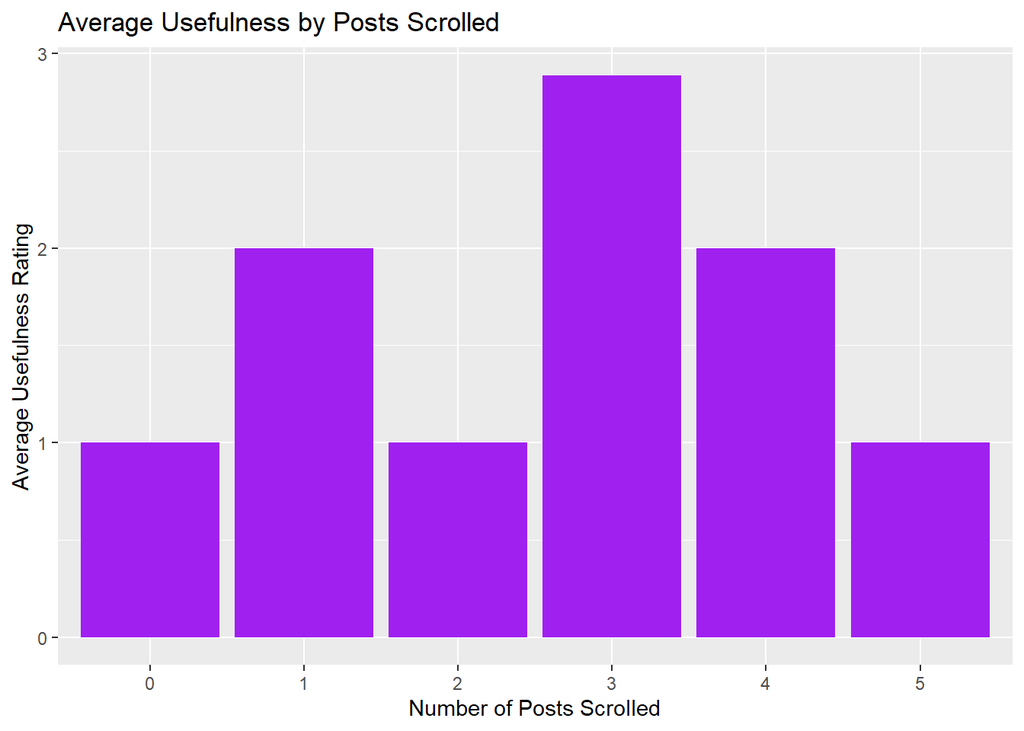

This report analyses how I interact with ads on my Instagram page by comparing how many posts I have to scroll through to get an ad and how useful/targeted that ad is to me personally.

Most of the ads are not useful for me at all as they are just mobile games or travel stuff, I don’t have any money to travel ANY TIME SOON. But the reason why I might be trageted with these ads might be because I went to India during the holidays and spent some time in Singapore as well. With the mobile ads, maybe it’s because the amount of Clash Royal I play.

Also another key finding is that it doesn’t take long to receive an ad on average after scrolling pat 3 posts I’m hit with an ad. This might be because most on the posts that I’m seeing aren’t by people I follow rather just random meme accounts that are just popping on my feed. This might be different if I’m follow more accounts that actually post stuff rather than 99% of my followings being my friends and family and the 1% is news/sport/gaming pages.

[figure not shown]